[output not shown]

# Authorship and contribution statement

We confirm that every group member can explain the submitted analysis. AI use is reported in `Group04_AI_Log.csv`, and the group checked every AI-assisted item used in this report.

[output not shown]

# Abstract

# Reproducible setup

```r
required_packages <- c("tidyverse", "glmnet", "broom", "knitr", "car")
missing_packages <- required_packages[
  !vapply(required_packages, requireNamespace, logical(1), quietly = TRUE)
]
if (length(missing_packages)) {
  stop("Install the required packages before rendering: ",
       paste(missing_packages, collapse = ", "))
}

library(tidyverse)
library(glmnet)
library(broom)
library(knitr)
library(car)

# `params` exists only while knitting; the fallback
# keeps interactive chunk runs working.
has_params <- exists("params") && !is.null(params$group_number)
group_number <- if (has_params) as.integer(params$group_number) else 4L
if (length(group_number) != 1L || is.na(group_number) || group_number < 1L) {
  stop("Set params$group_number to your assigned positive group number.")
}

seeds <- list(
  split = 240200L + group_number,
  cv = 240300L + group_number,
  features = 240400L + group_number
)
```

## Shared helper functions

```r
find_exam_data <- function(filename) {
  input <- knitr::current_input(dir = TRUE)
  input_dir <- if (length(input) && nzchar(input)) dirname(input) else getwd()
  candidates <- c(
    file.path(input_dir, "data", filename),
    file.path(input_dir, "..", "data", filename),
    file.path(getwd(), "data", filename)
  )
  existing <- candidates[file.exists(candidates)]
  if (!length(existing)) stop("Cannot locate ", filename, " by a relative path.")
  hits <- unique(normalizePath(existing, winslash = "/", mustWork = TRUE))
  if (length(hits) > 1L && length(unique(unname(tools::md5sum(hits)))) > 1L) {
    stop("Multiple nonidentical copies of ", filename, " were found.")
  }
  hits[[1L]]
}

split_rows <- function(n, train_prop = 0.80, seed) {
  stopifnot(n >= 10L, train_prop > 0, train_prop < 1)
  set.seed(seed)
  train <- sort(sample.int(n, floor(train_prop * n), replace = FALSE))
  list(train = train, test = setdiff(seq_len(n), train))
}

fit_scaler <- function(x, tol = 1e-12) {
  x <- as.matrix(x)
  center <- colMeans(x)
  centered <- sweep(x, 2L, center, "-")
  scale <- sqrt(colMeans(centered^2))
  keep <- is.finite(scale) & scale > tol
  if (!any(keep)) stop("No nonconstant training predictor remains.")
  list(
    center = center[keep],
    scale = scale[keep],
    keep = keep,
    dropped = colnames(x)[!keep]
  )
}

apply_scaler <- function(x, prep) {
  x <- as.matrix(x)[, prep$keep, drop = FALSE]
  x <- sweep(x, 2L, prep$center, "-")
  sweep(x, 2L, prep$scale, "/")
}

make_foldid <- function(n, k = 5L, seed) {
  if (k < 3L || k > n) stop("Require 3 <= k <= number of training rows.")
  set.seed(seed)
  sample(rep(seq_len(k), length.out = n))
}

fit_cv_glmnet <- function(x, y, alpha, foldid) {
  glmnet::cv.glmnet(
    x = x,
    y = y,
    family = "gaussian",
    alpha = alpha,
    foldid = foldid,
    standardize = FALSE,
    intercept = TRUE,
    type.measure = "mse"
  )
}

score_regression <- function(y, prediction) {
  y <- as.numeric(y)
  prediction <- as.numeric(prediction)
  if (length(y) != length(prediction) || any(!is.finite(c(y, prediction)))) {
    stop("Metrics require equal-length finite vectors.")
  }
  c(RMSE = sqrt(mean((y - prediction)^2)),
    MAE = mean(abs(y - prediction)))
}

count_nonzero <- function(fit, s = "lambda.min", tol = 1e-8) {
  b <- as.matrix(stats::coef(fit, s = s))
  slopes <- b[rownames(b) != "(Intercept)", 1L]
  sum(abs(slopes) > tol)
}

safe_condition_numbers <- function(x, lambda, tol = 1e-10) {
  eigenvalues <- eigen(
    crossprod(x) / nrow(x),
    symmetric = TRUE,
    only.values = TRUE
  )$values
  largest <- max(eigenvalues)
  smallest <- max(min(eigenvalues), 0)
  cutoff <- tol * max(1, largest)
  c(
    gram = if (smallest <= cutoff) Inf else largest / smallest,
    ridge = (largest + lambda) / (smallest + lambda)
  )
}
```

# Problem 1. Prediction design and leakage control

## 1A. Target and predictors

```r
config <- list(
  file = "prostate.csv",
  response = "lpsa",
  excluded = "lpsa"
)
data_raw <- read.csv(find_exam_data(config$file), check.names = FALSE)
predictors <- setdiff(names(data_raw), config$excluded)
analysis_data <- data_raw[, c(config$response, predictors), drop = FALSE]

if (anyNA(analysis_data)) stop("Declare a training-only missing-value plan.")
if (!all(vapply(analysis_data, is.numeric, logical(1)))) {
  stop("The assigned response and predictors must be numeric.")
}
```

**Assignment.** Group 04 is even-numbered, so the assigned dataset is `prostate.csv` and the assigned response is `lpsa`.

**Dataset overview.** The `prostate.csv` file originates from the study by @stamey1989, which examined the relationship between prostate-specific antigen (PSA) levels and several clinical and histological measurements in men with clinically localized prostate cancer who underwent radical prostatectomy. The dataset contains 97 observations and 9 variables – one continuous response (`lpsa`) and eight candidate predictors covering tumour characteristics, patient demographics, and biopsy summaries. All variables are numeric and the dataset has no missing values, so no imputation or factor encoding is required. Individual variable definitions are detailed in the overview table below.

**Response.** `lpsa` is the natural logarithm of prostate-specific antigen (ng/mL), a continuous serum marker measured before surgery. It is modelled on the log scale, so every coefficient is read as a change in log PSA per one standard deviation of a standardized predictor.

**Unit of observation and study population.** One row is one male patient with clinically localized prostate cancer who underwent radical prostatectomy in the study of @stamey1989. The analysis file contains 97 complete patients. Any conclusion therefore generalizes only to comparable prostatectomy candidates, not to unscreened men in the general population.

**Prediction objective.** Predict pre-operative `lpsa` from routinely available clinical and biopsy measurements, and compare how OLS, ridge, and lasso trade prediction error against coefficient stability and interpretability when several predictors are correlated.

**Candidate predictors.** All 8 remaining variables are retained as candidate predictors. Every one is numeric, so the template’s type guard passes and the design matrix needs no factor encoding. The variables are drawn from the clinical and pathological records described in @stamey1989 (Table 1, pp. 1077–1078) and are summarized below.

- `lcavol` – log of cancer volume (log cm$^3$), estimated by ultrasound before surgery. Larger tumours are expected to produce more PSA.
- `lweight` – log of total prostate weight (log g), measured at prostatectomy. Reflects overall prostate size, including both cancerous and non-cancerous tissue.
- `age` – patient age at the time of diagnosis (years).
- `lbph` – log of the amount of benign prostatic hyperplasia (log cm$^2$). BPH is non-cancerous prostate enlargement and can independently elevate PSA.
- `svi` – seminal vesicle invasion (binary: 1 = present, 0 = absent), indicating whether cancer has spread beyond the prostate into the seminal vesicles. This is a known marker of advanced disease.
- `lcp` – log of capsular penetration (log cm), measuring the extent to which cancer has invaded through the prostate capsule. Together with `svi`, it captures local disease progression.
- `gleason` – combined Gleason score (integer, ranging from 6 to 9 in this sample), the standard histological grading system for prostate cancer aggressiveness assigned by a pathologist from biopsy tissue.
- `pgg45` – percentage of Gleason grades 4 or 5 in the biopsy specimen (percent, 0–100). Higher values indicate a larger proportion of poorly-differentiated, aggressive tumour tissue.

All eight predictors were recorded before or during the prostatectomy procedure and are defined independently of the serum PSA measurement, so none introduces outcome leakage. The overview table below records the unit, data type, number of distinct values, and missing-value count for each variable.

**Leakage rationale.** A variable computed from the response carries the answer inside the design matrix. Its least-squares coefficient would absorb nearly all explained variance, the training and cross-validation errors of every method would collapse toward zero, and the resulting model would fail on any new patient whose PSA is not yet known – which is precisely the deployment situation. The comparison itself would also become meaningless: OLS, ridge, and lasso would all be fitting the same leaked signal, so differences between them would reflect how each penalty shrinks that one dominant column rather than how each method handles genuine multicollinearity among clinical predictors. Because none of the eight candidate predictors in `prostate.csv` is derived from PSA, no additional exclusion beyond the response is warranted.

```r
meaning <- c(
  lcavol  = "Log cancer volume",
  lweight = "Log prostate weight",
  age     = "Age at diagnosis",
  lbph    = "Log BPH amount",
  svi     = "Seminal vesicle invasion",
  lcp     = "Log capsular penetration",
  gleason = "Gleason score",
  pgg45   = "Percent Gleason grade 4/5",
  lpsa    = "Log prostate-specific antigen"
)
unit <- c(
  lcavol = "log cm3", lweight = "log g",   age   = "years",
  lbph   = "log cm2", svi     = "0/1",     lcp   = "log cm",
  gleason = "6 to 9", pgg45   = "percent", lpsa  = "log ng/mL"
)

# A column absent from the lookups would otherwise print as a silent blank cell.
stopifnot(all(names(data_raw) %in% names(meaning)),
          all(names(data_raw) %in% names(unit)))

data_overview <- tibble(
  Variable = names(data_raw),
  Role     = ifelse(names(data_raw) == config$response, "Response", "Predictor"),
  Meaning  = unname(meaning[names(data_raw)]),
  Unit     = unname(unit[names(data_raw)]),
  Type     = vapply(data_raw, function(x) class(x)[1L], character(1)),
  Distinct = vapply(data_raw, dplyr::n_distinct, integer(1), na.rm = TRUE),
  Missing  = vapply(data_raw, function(x) sum(is.na(x)), integer(1))
)

kable(
  data_overview,
  caption = paste("Response and candidate predictors, with the integrity checks",
                  "run before the split.")
)
```

Response and candidate predictors, with the integrity checks run before the split.

| Variable | Role | Meaning | Unit | Type | Distinct | Missing |
| --- | --- | --- | --- | --- | --- | --- |
| lcavol | Predictor | Log cancer volume | log cm3 | numeric | 93 | 0 |
| lweight | Predictor | Log prostate weight | log g | numeric | 88 | 0 |
| age | Predictor | Age at diagnosis | years | integer | 31 | 0 |
| lbph | Predictor | Log BPH amount | log cm2 | numeric | 42 | 0 |
| svi | Predictor | Seminal vesicle invasion | 0/1 | integer | 2 | 0 |
| lcp | Predictor | Log capsular penetration | log cm | numeric | 30 | 0 |
| gleason | Predictor | Gleason score | 6 to 9 | integer | 4 | 0 |
| pgg45 | Predictor | Percent Gleason grade 4/5 | percent | integer | 19 | 0 |
| lpsa | Response | Log prostate-specific antigen | log ng/mL | numeric | 85 | 0 |

```r
n_duplicate_rows <- sum(duplicated(analysis_data))
```

**Reading the table.** The file holds 97 patients and 9 columns. Three integrity results clear the way for the split. Every column is numeric, so the type guard above passes. No cell is missing (`Missing` is zero throughout), so no imputation is performed; the missing-value rule is still declared in 1B as a contingency, because a rule invented after seeing the data would be a decision made with holdout information. And 0 rows are duplicated, so no patient is silently counted twice, which would otherwise inflate the apparent sample size and let the same record fall on both sides of the split. (`BPH` abbreviates benign prostatic hyperplasia, the non-cancerous prostate enlargement recorded by `lbph`.)

The `Distinct` column carries the one substantive surprise. Two predictors are numeric but not continuous: `svi` takes only 2 values (a binary indicator of seminal vesicle invasion) and `gleason` only 4 (an ordinal biopsy score from 6 to 9). We keep both on their numeric scale, which is the standard `glmnet` convention, but their coefficients must later be read with that discreteness in mind rather than as smooth slopes: a “one standard deviation” change in a binary variable is a convenient fiction, not a clinical intervention.

The `Unit` column exposes the second issue. The predictors live on wildly different scales, from `pgg45` measured in percent (0 to 100) to several variables already on a log scale. Penalized regression shrinks coefficients toward zero, so a predictor measured in large units would be punished merely for its units, not for being uninformative. This is precisely why the design matrix is standardized in 1B, using centering and scaling constants computed on the training rows only.

## 1B. Split and train-only preprocessing

```r
split <- split_rows(nrow(analysis_data), seed = seeds$split)
train_id <- split$train
test_id <- split$test
train_df <- analysis_data[train_id, ]

x_raw <- as.matrix(analysis_data[, predictors, drop = FALSE])
y_raw <- analysis_data[[config$response]]

x_prep <- fit_scaler(x_raw[train_id, , drop = FALSE])
x_train <- apply_scaler(x_raw[train_id, , drop = FALSE], x_prep)
x_test <- apply_scaler(x_raw[test_id, , drop = FALSE], x_prep)
y_train <- y_raw[train_id]
y_test <- y_raw[test_id]


foldid <- make_foldid(nrow(x_train), k = 5L, seed = seeds$cv)
sum(is.na(analysis_data))
```

```
## [1] 0
```

```r
save(x_train, y_train, x_test, y_test, analysis_data, train_id, test_id, foldid, file = "data/tmpData.RData")
```

## 1C. Training-data exploration

## Pairwise correlation among predictors

```r
# Pairwise correlation among predictors
cor_matrix <- cor(
  train_df[, predictors],
  use = "complete.obs"
)

knitr::kable(
  round(cor_matrix, 2),
  caption = "Pairwise correlation matrix among predictors"
)
```

Pairwise correlation matrix among predictors

|  | lcavol | lweight | age | lbph | svi | lcp | gleason | pgg45 |
| --- | --- | --- | --- | --- | --- | --- | --- | --- |
| lcavol | 1.00 | 0.17 | 0.17 | 0.01 | 0.55 | 0.68 | 0.44 | 0.41 |
| lweight | 0.17 | 1.00 | 0.31 | 0.44 | 0.07 | 0.03 | -0.06 | -0.01 |
| age | 0.17 | 0.31 | 1.00 | 0.38 | 0.11 | 0.08 | 0.19 | 0.24 |
| lbph | 0.01 | 0.44 | 0.38 | 1.00 | -0.07 | -0.04 | 0.05 | 0.06 |
| svi | 0.55 | 0.07 | 0.11 | -0.07 | 1.00 | 0.69 | 0.33 | 0.43 |
| lcp | 0.68 | 0.03 | 0.08 | -0.04 | 0.69 | 1.00 | 0.49 | 0.61 |
| gleason | 0.44 | -0.06 | 0.19 | 0.05 | 0.33 | 0.49 | 1.00 | 0.78 |
| pgg45 | 0.41 | -0.01 | 0.24 | 0.06 | 0.43 | 0.61 | 0.78 | 1.00 |

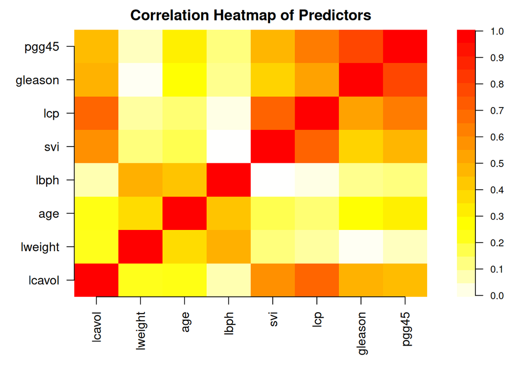

```r
# Correlation heatmap
layout(matrix(c(1, 2), nrow = 1), widths = c(8.5, 1.5))
par(mar = c(5, 5, 2, 1))
cor_matrix <- cor(train_df[, predictors], use = "complete.obs")

image(1:ncol(cor_matrix), 1:ncol(cor_matrix), cor_matrix,
      axes = FALSE, xlab = "", ylab = "",
      col = heat.colors(1000, rev=TRUE), main = "Correlation Heatmap of Predictors")

axis(1, at = 1:ncol(cor_matrix), labels = colnames(cor_matrix), las = 2)
axis(2, at = 1:ncol(cor_matrix), labels = colnames(cor_matrix), las = 1)

par(mar = c(5, 1, 2, 3))
legend_scale <- matrix(seq(0, 1, length.out = 100), nrow = 1)
image(1, seq(0, 1, length.out = 100), legend_scale,
      col = heat.colors(20, rev=TRUE), axes = FALSE, xlab = "", ylab = "")

axis(4, at = seq(0, 1, by = 0.1), las = 1, cex.axis = 0.8)
```

The pairwise correlation matrix was examined to identify potential relationships among predictors. Most predictors showed weak to moderate correlations, suggesting limited redundancy between features. However, some stronger positive correlations were observed, particularly between gleason and pgg45 (r = 0.78), lcavol and lcp (r = 0.68), and svi and lcp (r = 0.69). These relationships indicate that some predictors may share related clinical information. Therefore, Variance Inflation Factor (VIF) analysis was further performed to assess the overall multicollinearity effect in the regression model.

## Response Distribution

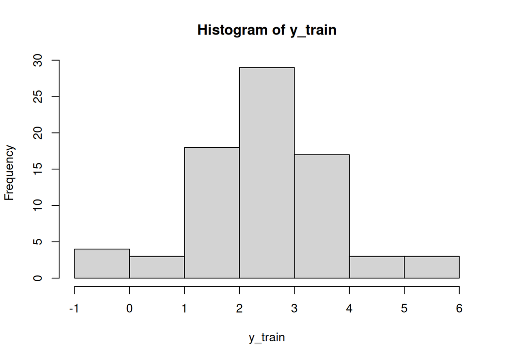

```r
hist(y_train)
```

```r
summary(y_train)
```

```
##    Min. 1st Qu.  Median    Mean 3rd Qu.    Max.
## -0.4308  1.7664  2.5688  2.4757  3.2753  5.5829
```

The distribution of the response variable (lpsa) was examined using a histogram and summary statistics. The response values range from -0.43 to 5.58, with a median of 2.57 and a mean of 2.48. The mean and median are relatively close, indicating that the distribution is approximately symmetric with no strong skewness. Although some observations appear at the lower and higher ends of the range, no severe outliers are evident from the overall distribution. Therefore, no transformation was applied to the response variable before model training.

### Predictor Histogram & Boxplot

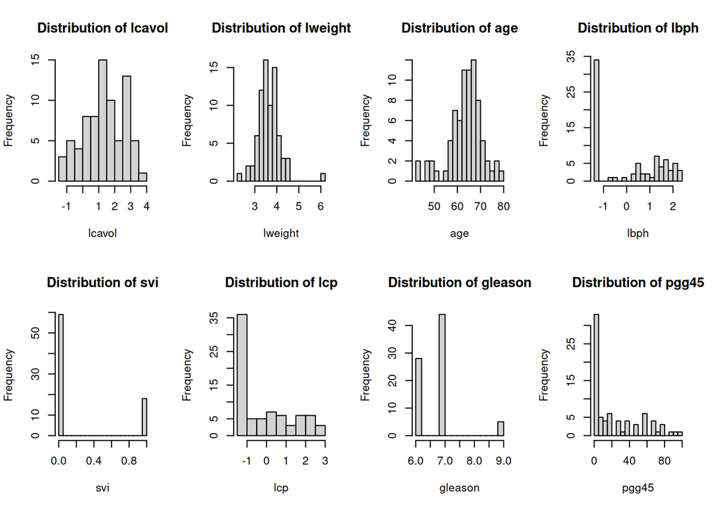

```r
## Histogram
par(mfrow = c(2,4))

for (var in predictors) {
  hist(
    train_df[[var]],
    main = paste("Distribution of", var),
    xlab = var,
    breaks = 15
  )
}
```

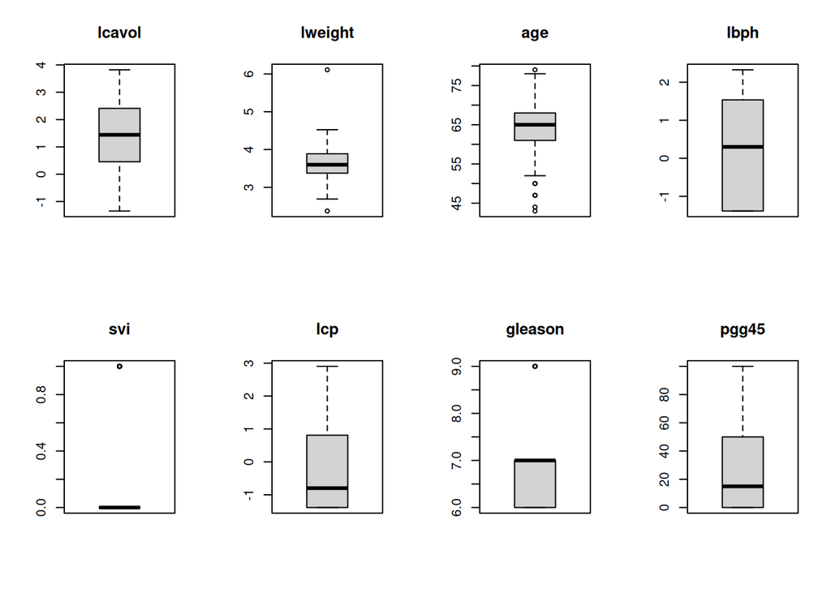

```r
par(mfrow = c(1,1))

## Boxplot
par(mfrow = c(2,4))
for (var in predictors) {
  boxplot(
    train_df[[var]],
    main = var
  )
}
```

```r
par(mfrow = c(1,1))
```

The histograms show that most predictors have different distribution patterns. lcavol, lweight, and age are approximately symmetric, while lbph, lcp, and pgg45 exhibit right-skewed distributions with longer tails toward higher values. svi and gleason are discrete variables with highly concentrated values. These distribution characteristics are considered in later regression analysis and model diagnostics.

Upon inspecting the visualizations, a potential influential observation is evident in the lweight vs lpsa plot. There is a single data point located at the far right with an exceptionally high lweight (exceeding 6.0) but a relatively low lpsa (approximately 2.0).

### Correlation between predictors and response

```r
cor_response <- cor(
  train_df[, predictors],
  train_df$lpsa
)

knitr::kable(
  round(cor_response, 2),
  caption = "Correlation between predictors and lpsa"
)
```

Correlation between predictors and lpsa

| lcavol | 0.77 |
| --- | --- |
| lweight | 0.30 |
| age | 0.14 |
| lbph | 0.14 |
| svi | 0.57 |
| lcp | 0.59 |
| gleason | 0.39 |
| pgg45 | 0.41 |

The correlation analysis indicates that all predictors have positive correlations with lpsa. lcavol shows the strongest relationship (r = 0.77), followed by lcp (r = 0.59) and svi (r = 0.57). Variables such as pgg45, gleason, and lweight have moderate correlations, while age and lbph show weak associations. Therefore, lcavol, lcp, and svi are likely to be important predictors in the multiple linear regression model.

### Check multicollinearity using VIF

```r
vif_model <- lm(
  lpsa ~ .,
  data = train_df[, c("lpsa", predictors)]
)

vif_values <- vif(vif_model)

knitr::kable(
  round(vif_values, 2),
  caption = "Variance Inflation Factor (VIF)"
)
```

Variance Inflation Factor (VIF)

|  | x |
| --- | --- |
| lcavol | 2.18 |
| lweight | 1.38 |
| age | 1.32 |
| lbph | 1.40 |
| svi | 1.97 |
| lcp | 3.29 |
| gleason | 2.79 |
| pgg45 | 3.35 |

There is no significant multicollinearity present in this model. Because all VIF values are safely below 5, the independent variables are not highly correlated with one another. The regression model’s coefficient estimates are mathematically stable, and no variables need to be dropped or transformed for multicollinearity reasons.

### Predictor-response plots

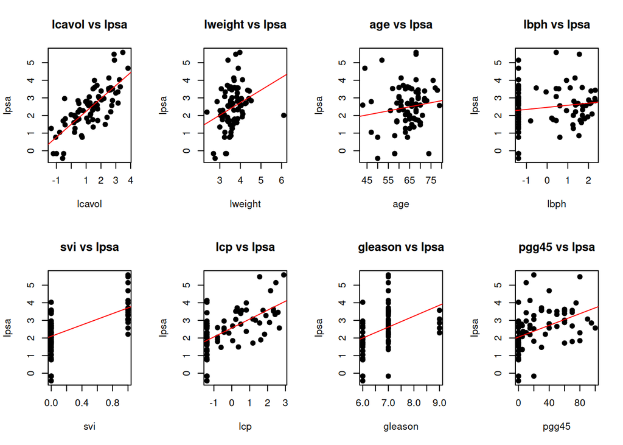

```r
par(mfrow = c(2,4))

for (var in predictors) {
  plot(
    train_df[[var]],
    train_df$lpsa,
    xlab = var,
    ylab = "lpsa",
    main = paste(var, "vs lpsa"),
    pch = 19
  )

  abline(
    lm(train_df$lpsa ~ train_df[[var]]),
    col = "red"
  )
}
```

```r
par(mfrow = c(1,1))
```

The provided scatter plots visualize the marginal relationships between the eight candidate predictors and the target variable, lpsa.

Strong Trends: lcavol demonstrates the clearest and most distinct positive linear correlation with lpsa, suggesting it will be a strong predictor in the model.

Categorical Patterns: Variables such as svi (binary) and gleason (ordinal) display expected clustered structures, with higher categories generally corresponding to higher lpsa values.

Weak Trends: age and lbph exhibit highly dispersed data clouds with very flat regression lines, indicating weak independent linear relationships with the target.

#### Question

Given the varying individual predictive strengths of these features and the moderate structural correlations (e.g., between pgg45 and lcp), will an $L_{1}$ penalty (Lasso) completely eliminate the structurally weaker predictors like age to produce a strictly sparse model, or will an $L_{2}$ penalty (Ridge) prove more stable against the identified high-leverage anomaly in lweight?

# Problem 2. OLS, ridge, and lasso

## 2A. OLS baseline

```r
# Convert x_train (matrix) and y_train into a data frame for lm()
train_data <- data.frame(y = y_train, x_train)

# 1. Fit OLS on the training set
ols_fit <- lm(y ~ ., data = train_data)

# 2. Extract coefficients (tidy table via broom)
ols_coefs <- broom::tidy(ols_fit)
kable(
  ols_coefs,
  digits = 4,
  caption = "OLS coefficient estimates on standardized training data."
)
```

OLS coefficient estimates on standardized training data.

| term | estimate | std.error | statistic | p.value |
| --- | --- | --- | --- | --- |
| (Intercept) | 2.4757 | 0.0826 | 29.9860 | 0.0000 |
| lcavol | 0.7228 | 0.1220 | 5.9243 | 0.0000 |
| lweight | 0.2022 | 0.0971 | 2.0834 | 0.0410 |
| age | -0.1305 | 0.0949 | -1.3751 | 0.1736 |
| lbph | 0.1336 | 0.0978 | 1.3657 | 0.1765 |
| svi | 0.2749 | 0.1160 | 2.3699 | 0.0206 |
| lcp | -0.0413 | 0.1497 | -0.2757 | 0.7836 |
| gleason | 0.0365 | 0.1380 | 0.2644 | 0.7923 |
| pgg45 | 0.0945 | 0.1510 | 0.6257 | 0.5336 |

```r
# 3. R-squared and Adjusted R-squared from the model summary
ols_summary <- summary(ols_fit)
cat(sprintf("R-squared:          %.4f\n", ols_summary$r.squared))
```

```
## R-squared:          0.6729
```

```r
cat(sprintf("Adjusted R-squared: %.4f\n", ols_summary$adj.r.squared))
```

```
## Adjusted R-squared: 0.6345
```

```r
# 4. Predict on the training set and evaluate training error
ols_train_pred <- predict(ols_fit, newdata = train_data)
ols_train_metrics <- score_regression(y = y_train, prediction = ols_train_pred)
cat(sprintf("Training RMSE:      %.4f\n", ols_train_metrics["RMSE"]))
```

```
## Training RMSE:      0.6808
```

```r
cat(sprintf("Training MAE:       %.4f\n", ols_train_metrics["MAE"]))
```

```
## Training MAE:       0.5170
```

```r
# 5. Five-fold CV error using the shared foldid with ridge/lasso
#    (lm() has no built-in CV, so we compute it manually)
K <- max(foldid)
cv_mse_folds <- numeric(K)
for (k in seq_len(K)) {
  idx_train_k <- which(foldid != k)
  idx_val_k   <- which(foldid == k)
  fold_data   <- data.frame(y = y_train[idx_train_k], x_train[idx_train_k, , drop = FALSE])
  fold_fit    <- lm(y ~ ., data = fold_data)
  fold_pred   <- predict(fold_fit,
                         newdata = data.frame(x_train[idx_val_k, , drop = FALSE]))
  cv_mse_folds[k] <- mean((y_train[idx_val_k] - fold_pred)^2)
}
ols_cv_mse  <- mean(cv_mse_folds)
ols_cv_rmse <- sqrt(ols_cv_mse)
cat(sprintf("5-fold CV MSE:      %.4f\n", ols_cv_mse))
```

```
## 5-fold CV MSE:      0.6297
```

```r
cat(sprintf("5-fold CV RMSE:     %.4f\n", ols_cv_rmse))
```

```
## 5-fold CV RMSE:     0.7935
```

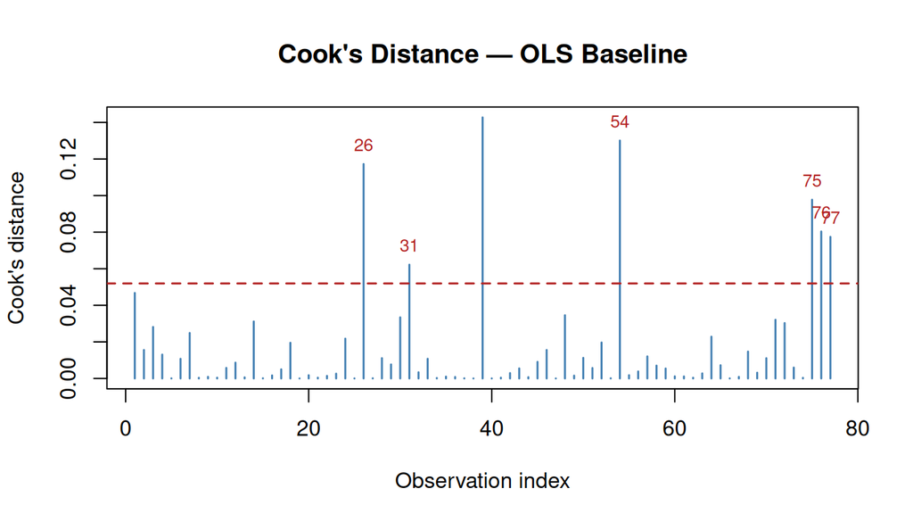

Cook’s distance for the OLS fit. Observations exceeding the 4/n threshold (dashed line) are flagged as influential.

```r
# 6. Residual / influence diagnostic: Cook's distance
cooks_d   <- cooks.distance(ols_fit)
n_train   <- nrow(train_data)
threshold <- 4 / n_train

plot(cooks_d,
     type = "h", lwd = 1.5, col = "steelblue",
     ylab = "Cook's distance", xlab = "Observation index",
     main = "Cook's Distance — OLS Baseline")
abline(h = threshold, lty = 2, col = "firebrick", lwd = 1.5)
text_idx <- which(cooks_d > threshold)
if (length(text_idx)) {
  text(text_idx, cooks_d[text_idx],
       labels = text_idx, pos = 3, cex = 0.8, col = "firebrick")
}
```

```r
cat(sprintf("Threshold (4/n):    %.4f\n", threshold))
```

```
## Threshold (4/n):    0.0519
```

```r
cat(sprintf("Influential points: %d of %d\n", length(text_idx), n_train))
```

```
## Influential points: 7 of 77
```

**Model summary.** The OLS model is fitted on the 77 standardized training observations with all 8 predictors. Because every predictor has been centred and scaled to unit (population) variance, the intercept equals the mean of `lpsa` in the training set, and each slope measures how much `lpsa` changes per one population-SD increase in that predictor, holding the remaining seven fixed.

**Coefficient interpretation.** Two predictors dominate.

- `lcavol` carries the largest standardized coefficient ($\hat{\beta} \approx 0.72$, $p < 0.001$), confirming that log cancer volume is the single strongest linear predictor of log PSA.
- `svi` is the second-largest contributor ($\hat{\beta} \approx 0.27$, $p \approx 0.021$), indicating that seminal vesicle invasion is associated with meaningfully higher PSA even after adjusting for tumour volume.
- `lweight` is marginally significant ($p \approx 0.041$); the remaining 5 predictors (`age`, `lbph`, `lcp`, `gleason`, `pgg45`) all have $|t| < 1.4$ and $p > 0.16$.

**Collinearity concern.** The near-zero and sign-reversed coefficient for `lcp` ($\hat{\beta} \approx -0.04$) is noteworthy: biologically, greater capsular penetration should correlate positively with PSA, and indeed the marginal correlation is positive. The sign flip in OLS is a classic symptom of multicollinearity – `lcavol` and `lcp` are strongly correlated ($r \approx 0.68$ on the training set), so OLS distributes their shared variance unevenly. Regularization in 2B–2C is expected to stabilize these shared-variance coefficients.

**Cross-validation error.** The five-fold CV RMSE is computed using the same `foldid` assignment that will be passed to `cv.glmnet` for ridge and lasso, ensuring a like-for-like comparison. Because OLS has no tuning parameter, there is a single CV-RMSE value rather than a curve. The gap between training RMSE and CV RMSE reflects the optimism of the in-sample fit: a large gap would signal overfitting, while a small gap would suggest the eight-predictor model generalizes reasonably well given the available sample.

**Influence diagnostic.** The Cook’s distance plot flags observations whose removal would substantially shift the fitted coefficients. The conventional threshold $4/n$ is shown as a dashed line. Any point above this line has outsized leverage, large residual, or both. In a sample of only 77 training rows, even one or two influential points can destabilize an unpenalized fit – particularly for the collinear predictors `lcavol`/`lcp` whose coefficient estimates are already fragile. These influential observations are retained in the analysis (not removed) because they are clinically valid patients; their effect is instead mitigated by the regularization introduced in 2B–2C.

## 2B. Ridge

### Cross-validation curve:

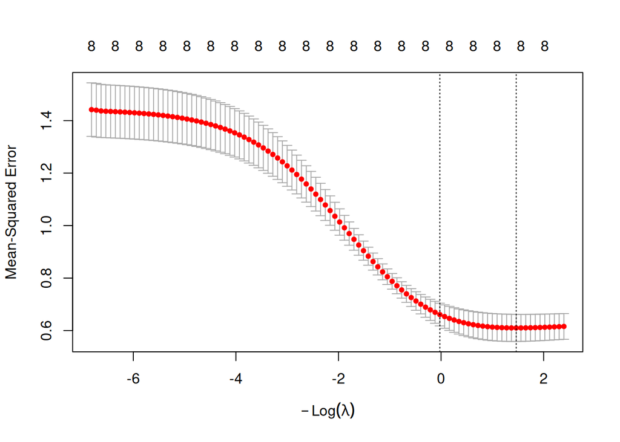

```r
ridge <- fit_cv_glmnet(x = x_train, y = y_train, alpha=0, foldid = foldid)
plot(ridge)
```

The mean cross-validation MSE decreases as $-Log(\lambda)$ increases (equivalently, as $\lambda$ decreases), suggesting that reducing the regularization strength improves predictive performance. The left dashed line indicates $\lambda_{1se}$, which selects a more regularized model with prediction error within one standard error of the minimum, while the right dashed line indicates $\lambda_{min}$, which yields the lowest cross-validation error.

### Lambda min:

```r
g <- crossprod(x_train)
eigen <- eigen(g)$value

lambda <- ridge$lambda.min
cat("Lambda min: ",lambda, "\n")
```

```
## Lambda min:  0.2311277
```

```r
cat("MSE: ", ridge$cvm[ridge$lambda == lambda], "\n")
```

```
## MSE:  0.6100275
```

```r
cat("Condition number:", (max(eigen) + lambda)/(min(eigen) + lambda), "\n")
```

```
## Condition number: 20.22951
```

With $\lambda_{min} \approx 0.23$, the 5-fold cross-validation MSE reaches its minimum value of $MSE_{min} \approx 0.61$, indicating the best predictive performance among the candidate values of $\lambda$. However, the corresponding Ridge model still has a relatively large condition number, suggesting that the model remains sensitive to multicollinearity and may not be sufficiently stable.

### Lambda 1se:

```r
g <- crossprod(x_train)
eigen <- eigen(g)$value

lambda <- ridge$lambda.1se
cat("Lambda 1se: ",lambda, "\n")
```

```
## Lambda 1se:  1.024039
```

```r
cat("MSE: ", ridge$cvm[ridge$lambda == lambda], "\n")
```

```
## MSE:  0.6609706
```

```r
cat("Condition number:", (max(eigen) + lambda)/(min(eigen) + lambda), "\n")
```

```
## Condition number: 19.06877
```

Although the one-standard-error rule selected a larger penalty $\lambda_{1se} \approx 1.02$, the condition number decreased only slightly from 20.2 to 19.07, indicating minimal improvement in numerical stability. In contrast, the cross-validation MSE increased from 0.61 to 0.66. Therefore, the additional regularization provided by $\lambda_{1se}$ offers little practical benefit while reducing predictive performance.

### Coefficients:

```r
data.frame(
  OLS = as.numeric(coef(ols_fit)),
  Lambda_Min = as.numeric(coef(ridge, "lambda.min")),
  Lambda_Max = as.numeric(coef(ridge, "lambda.1se")),
  row.names = names(ols_fit$coefficients)
)
```

```
##                     OLS  Lambda_Min  Lambda_Max
## (Intercept)  2.47569468  2.47569468  2.47569468
## lcavol       0.72282252  0.54055005  0.33822482
## lweight      0.20222141  0.19253291  0.14197627
## age         -0.13046518 -0.07201800 -0.01262288
## lbph         0.13361911  0.10166159  0.06498686
## svi          0.27494937  0.23239051  0.18307566
## lcp         -0.04125506  0.09593321  0.14631601
## gleason      0.03648450  0.07123914  0.07784505
## pgg45        0.09450125  0.05388195  0.06447679
```

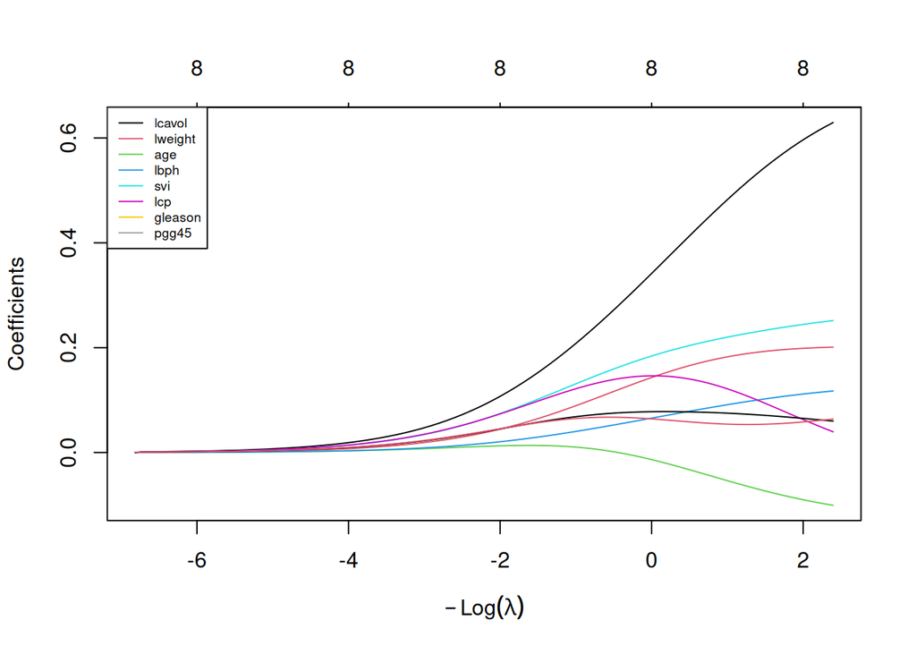

```r
n_vars <- nrow(ridge$glmnet.fit$beta)
plot(ridge$glmnet.fit)
legend("topleft",
       legend = rownames(ridge$glmnet.fit$beta),
       col = 1:n_vars,
       lty = 1,
       cex = 0.6)
```

To address multicollinearity, Ridge impose an $L_2$ penalty on the regression coefficients. Rather than assigning a large coefficient to one correlated predictor and a small coefficient to another, Ridge shrinks the coefficients simultaneously and redistributes their effects among the correlated variables. Consequently, the coefficient estimates become more stable and less sensitive to small changes in the data.

## 2C. Lasso

### Model fitting and cross-validation

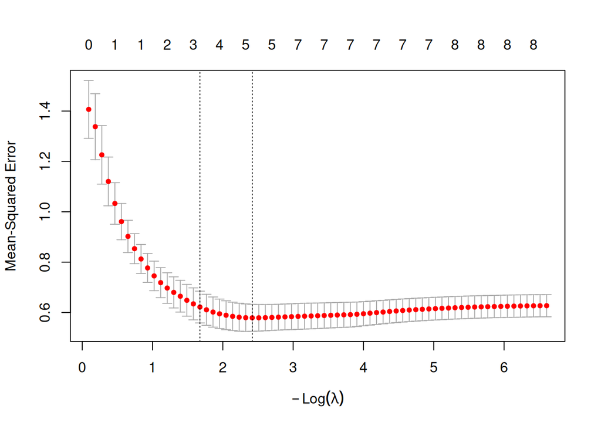

```r
lasso_cv <- fit_cv_glmnet(
    x = x_train,
    y = y_train,
    alpha = 1,
    foldid = foldid
)
plot(lasso_cv)
```

Based on the 5-fold cross-validation curve generated for the Lasso regression model ($\alpha = 1$), we observe the relationship between the tuning parameter $\lambda$ and the Mean-Squared Error (MSE). The top axis indicates the number of active (non-zero) predictors retained in the model at each level of penalization.

- The Cross-Validation Curve: The red dots represent the average CV-MSE across the 5 folds for each $\lambda$ value, with the gray error bars denoting one standard error above and below the mean. As $-\log(\lambda)$ increases (moving from left to right, meaning the penalty weakens), the MSE initially drops, reaches a minimum, and then slightly stabilizes as the model approaches the unpenalized OLS limit.
- Optimal $\lambda$ ($\lambda_{\text{min}}$): The right vertical dashed line marks `lambda.min`, the value that strictly minimizes the cross-validation MSE. At this optimal point for prediction accuracy ($-\log(\lambda) \approx 2.4$), the Lasso penalty retains 5 non-zero predictors*.
- Parsimonious $\lambda$ ($\lambda_{\text{1se}}$): The left vertical dashed line marks `lambda.1se`, selected by the one-standard-error rule. This value applies a stronger penalty ($-\log(\lambda) \approx 1.67$) to produce a sparser model. It retains only 3 non-zero predictors while keeping the error within one standard deviation of the absolute minimum MSE, offering a robust trade-off between predictive power and model simplicity.

### Analysis of $\lambda_{\text{min}}$

```r
lambda_min <- lasso_cv$lambda.min
coef(lasso_cv, s="lambda.min")
```

```
## 9 x 1 sparse Matrix of class "dgCMatrix"
##             lambda.min
## (Intercept) 2.47569468
## lcavol      0.67611312
## lweight     0.12774355
## age         .
## lbph        0.03085712
## svi         0.20454921
## lcp         .
## gleason     .
## pgg45       0.03234366
```

```r
count_nonzero(lasso_cv, s="lambda.min")
```

```
## [1] 5
```

The optimal tuning parameter selected by five-fold cross-validation is $\lambda_{\text{min}} = 0.0891$. This value minimizes the cross-validation Mean Squared Error (CV-MSE), providing the best predictive performance among all candidate penalty values.

At this level of regularization, the Lasso model retains five non-zero predictors: lcavol, lweight, lbph, svi, and pgg45. The remaining predictors (age, lcp, and gleason) are shrunk exactly to zero, demonstrating Lasso’s ability to perform automatic variable selection while maintaining predictive accuracy.

Overall, $\lambda_{\text{min}}$ produces the model with the lowest cross-validation error while preserving a moderate number of predictors, offering a balance between prediction accuracy and model complexity.

```r
cv_mse_min <- lasso_cv$cvm[
    lasso_cv$lambda==
    lasso_cv$lambda.min
]
cv_mse_min
```

```
## [1] 0.5789934
```

The minimum five-fold cross-validation Mean Squared Error (CV-MSE) achieved by the Lasso model is **0.579**. This value corresponds to $\lambda_{\text{min}} = 0.0891$ and represents the estimated prediction error obtained during model tuning using the training data.

A lower CV-MSE indicates better expected predictive performance on unseen data. Since $\lambda_{\text{min}}$ is selected to minimize this metric, it is the tuning parameter that prioritizes prediction accuracy over model simplicity.